# An Impact of Weather Events on a Health and Economic

Andrey Zaitcev

20 June 2016

# Synopsis

Weather has a huge affect on people lifes, economics, countries. Normal weather (depending on a region) helps to develop economics and improve peoples life, but bad weather can lead to fatalities, injures and huge material losses. Gathering and researching the information about weather events and caused effects can help to reduce the harm.  
This project involves exploring the U.S. National Oceanic and Atmospheric Administration’s (NOAA) storm database. This database tracks characteristics of major storms and weather events in the United States, including when and where they occur, as well as estimates of any fatalities, injuries, and property damage. Report contains results of exploratory analysis of the impact on health and economics different weather events based on data from NOAA Storm Database.

Results of the analysis: Tornado and Excessive Heat are the top2 most dangerous weather events, Flood causes most property damage, Drought causes most crop damage.

# Dataset info

Dataset [NOAA Storm Database](https://d396qusza40orc.cloudfront.net/repdata%2Fdata%2FStormData.csv.bz2) [46.9MB] The events in the database start in the year 1950 and end in November 2011. In the earlier years of the database there are generally fewer events recorded, most likely due to a lack of good records. More recent years should be considered more complete.

# 1. Goals

The main goal of the research is to explore the NOAA’s dataset and answer the questions:

- Across the United States, which types of events (as indicated in the EVTYPE variable) are most harmful with respect to population health?
- Across the United States, which types of events have the greatest economic consequences?

# 2. Environment and development info

```r
#load dependencies
library(R.utils)
library(ggplot2)
library(gridExtra)
library(dplyr)

# get software environment
```

# 3. Data processing.

## 3.1 Loading the data

! by default the data will be saved in your current work directory!

Steps to load the data:

1. Save url to file in fileUrl variable
2. Create data subfolder and download dataset in this folder.
3. Unpack the data
4. Chech the file size.

```r
# download dataset
fileUrl <- "https://d396qusza40orc.cloudfront.net/repdata%2Fdata%2FStormData.csv.bz2"
if(!file.exists("./data")){dir.create("./data")}
download.file(fileUrl,destfile="./data/StormData.csv.bz2")

#unzip file, this operation speeds up reading the data
bunzip2("./data/StormData.csv.bz2", "./data/StormData.csv", remove = FALSE, skip = TRUE)
```

```
## [1] "./data/StormData.csv"
## attr(,"temporary")
## [1] FALSE
```

```r
#before loading a data set check a size of it
size_of_file <- (file.info("./data/StormData.csv")$size)/2^20
size_of_file
```

```
## [1] 535.6192
```

Now let’s load the data and see what there are in it.

```r
#loading dataset
source_df <- read.csv("./data/StormData.csv", header = TRUE, stringsAsFactors = FALSE)

#look at the data
head(source_df)
```

```
##   STATE__           BGN_DATE BGN_TIME TIME_ZONE COUNTY COUNTYNAME STATE
## 1       1  4/18/1950 0:00:00     0130       CST     97     MOBILE    AL
## 2       1  4/18/1950 0:00:00     0145       CST      3    BALDWIN    AL
## 3       1  2/20/1951 0:00:00     1600       CST     57    FAYETTE    AL
## 4       1   6/8/1951 0:00:00     0900       CST     89    MADISON    AL
## 5       1 11/15/1951 0:00:00     1500       CST     43    CULLMAN    AL
## 6       1 11/15/1951 0:00:00     2000       CST     77 LAUDERDALE    AL
##    EVTYPE BGN_RANGE BGN_AZI BGN_LOCATI END_DATE END_TIME COUNTY_END
## 1 TORNADO         0                                               0
## 2 TORNADO         0                                               0
## 3 TORNADO         0                                               0
## 4 TORNADO         0                                               0
## 5 TORNADO         0                                               0
## 6 TORNADO         0                                               0
##   COUNTYENDN END_RANGE END_AZI END_LOCATI LENGTH WIDTH F MAG FATALITIES
```

[output cut: 20 more lines]

```r
str(source_df)
```

```
## 'data.frame':    902297 obs. of  37 variables:
##  $ STATE__   : num  1 1 1 1 1 1 1 1 1 1 ...
##  $ BGN_DATE  : chr  "4/18/1950 0:00:00" "4/18/1950 0:00:00" "2/20/1951 0:00:00" "6/8/1951 0:00:00" ...
##  $ BGN_TIME  : chr  "0130" "0145" "1600" "0900" ...
##  $ TIME_ZONE : chr  "CST" "CST" "CST" "CST" ...
##  $ COUNTY    : num  97 3 57 89 43 77 9 123 125 57 ...
##  $ COUNTYNAME: chr  "MOBILE" "BALDWIN" "FAYETTE" "MADISON" ...
##  $ STATE     : chr  "AL" "AL" "AL" "AL" ...
##  $ EVTYPE    : chr  "TORNADO" "TORNADO" "TORNADO" "TORNADO" ...
##  $ BGN_RANGE : num  0 0 0 0 0 0 0 0 0 0 ...
##  $ BGN_AZI   : chr  "" "" "" "" ...
##  $ BGN_LOCATI: chr  "" "" "" "" ...
##  $ END_DATE  : chr  "" "" "" "" ...
##  $ END_TIME  : chr  "" "" "" "" ...
##  $ COUNTY_END: num  0 0 0 0 0 0 0 0 0 0 ...
```

[output cut: 23 more lines]

## 3.3 Subsetting the data

As it seems, for further research we need columns: EVTYPE,FATALITIES, INJURIES, PROPDMG,PROPDMGEXP, CROPDMG, CROPDMGEXP

- EVTYPE - type of weather events.
- FATALITIES - number of fatalities causes by weather event.
- INJURIES - number of unjures causes by weather event.

Property damage is represented with two fields, a number PROPDMG in dollars and the exponent PROPDMGEXP.

Similarly, the crop damage is represented using two fields, CROPDMG and CROPDMGEXP.

```r
# get neccesary data
damage_df <- select(source_df, EVTYPE,FATALITIES, INJURIES, PROPDMG,PROPDMGEXP, CROPDMG, CROPDMGEXP)
```

## 3.4 Data transformations.

Before doing any calculations we need to prepare the data.

Preparing the property damage data:

1. Convert PROPDMGEXP to factor
2. Get the unique levels, to get a range of all elements.
3. Convert explonent to a numeric value, according to the range of variables from step 2.
4. Multiply PROPDMG with exponent value from step 3.
5. Do the same for the crop.

```r
#prepare property damamge data
damage_df$PROPDMGEXP <- as.factor(damage_df$PROPDMGEXP)
unique(damage_df$PROPDMGEXP)
```

```
##  [1] K M   B m + 0 5 6 ? 4 2 3 h 7 H - 1 8
## Levels:  - ? + 0 1 2 3 4 5 6 7 8 B h H K m M
```

As it seems we’ve got a range of variables, that needs to be converted to get correct damage value.

```r
# converting the property exp data
damage_df$PROPEXP[damage_df$PROPDMGEXP == "0"] <- 1
damage_df$PROPEXP[damage_df$PROPDMGEXP == "1"] <- 10
damage_df$PROPEXP[damage_df$PROPDMGEXP == "h"] <- 1e+02
damage_df$PROPEXP[damage_df$PROPDMGEXP == "2"] <- 1e+02
damage_df$PROPEXP[damage_df$PROPDMGEXP == "H"] <- 1e+02
damage_df$PROPEXP[damage_df$PROPDMGEXP == "K"] <- 1e+03
damage_df$PROPEXP[damage_df$PROPDMGEXP == "3"] <- 1e+04
damage_df$PROPEXP[damage_df$PROPDMGEXP == "4"] <- 1e+04
damage_df$PROPEXP[damage_df$PROPDMGEXP == "5"] <- 1e+05
damage_df$PROPEXP[damage_df$PROPDMGEXP == "m"] <- 1e+06
damage_df$PROPEXP[damage_df$PROPDMGEXP == "M"] <- 1e+06
damage_df$PROPEXP[damage_df$PROPDMGEXP == "6"] <- 1e+06
damage_df$PROPEXP[damage_df$PROPDMGEXP == "7"] <- 1e+07
damage_df$PROPEXP[damage_df$PROPDMGEXP == "8"] <- 1e+08
damage_df$PROPEXP[damage_df$PROPDMGEXP == "B"] <- 1e+09

# give 0 to invalid data, so they not count in
damage_df$PROPEXP[damage_df$PROPDMGEXP == "+"] <- 0
damage_df$PROPEXP[damage_df$PROPDMGEXP == "-"] <- 0
damage_df$PROPEXP[damage_df$PROPDMGEXP == "?"] <- 0
damage_df$PROPEXP[damage_df$PROPDMGEXP == ""] <-  0
# compute the property damage value
damage_df$PROPDMGVAL <- damage_df$PROPDMG * damage_df$PROPEXP
```

Preparing the crop damage data

```r
# prepare crop damage data
# Sorting the crop  exponent data
damage_df$CROPDMGEXP <- as.factor(damage_df$CROPDMGEXP)
unique(damage_df$CROPDMGEXP)
```

```
## [1]   M K m B ? 0 k 2
## Levels:  ? 0 2 B k K m M
```

As it seems we’ve got a range of variables, that needs to be converted to get correct damage value.

```r
# converting the crop exp data
damage_df$CROPEXP[damage_df$CROPDMGEXP == "0"] <- 1
damage_df$CROPEXP[damage_df$CROPDMGEXP == "2"] <- 1e+02
damage_df$CROPEXP[damage_df$CROPDMGEXP == "k"] <- 1e+03
damage_df$CROPEXP[damage_df$CROPDMGEXP == "K"] <- 1e+03
damage_df$CROPEXP[damage_df$CROPDMGEXP == "m"] <- 1e+06
damage_df$CROPEXP[damage_df$CROPDMGEXP == "M"] <- 1e+06
damage_df$CROPEXP[damage_df$CROPDMGEXP == "B"] <- 1e+09

# give 0 to invalid  data, so they not count in
damage_df$CROPEXP[damage_df$CROPDMGEXP == "?"] <- 0
damage_df$CROPEXP[damage_df$CROPDMGEXP == ""] <-  0

# compute the property damage value
damage_df$CROPDMGVAL <- damage_df$CROPDMG * damage_df$CROPEXP
```

## 3.5 Aggregating prepared data by type of event.

To get the answer for the 1,2 question we need to sum the number of fatalities, injures and damage value by event types and save it in appropriate variables, that will be used in next step.

```r
#aggregate the data
agg_fatalities <- aggregate(damage_df$FATALITIES, by=list(damage_df$EVTYPE),FUN=sum, na.rm=FALSE)
agg_injures <- aggregate(damage_df$INJURIES, by=list(damage_df$EVTYPE),FUN=sum, na.rm=FALSE)
agg_prop_damage <- aggregate(damage_df$PROPDMGVAL, by=list(damage_df$EVTYPE),FUN=sum, na.rm=FALSE)
agg_crop_damage <- aggregate(damage_df$CROPDMGVAL, by=list(damage_df$EVTYPE),FUN=sum, na.rm=FALSE)
```

# 4. Results

## Q1. Across the United States, which types of events (as indicated in the EVTYPE variable) are most harmful with respect to popuulation health?

Steps to plot the graph:

1. Order by number of fatalities
2. Get top 10 of the list
3. Convert evtype to factor.
4. Plot the graps

Similary i do for the injures.

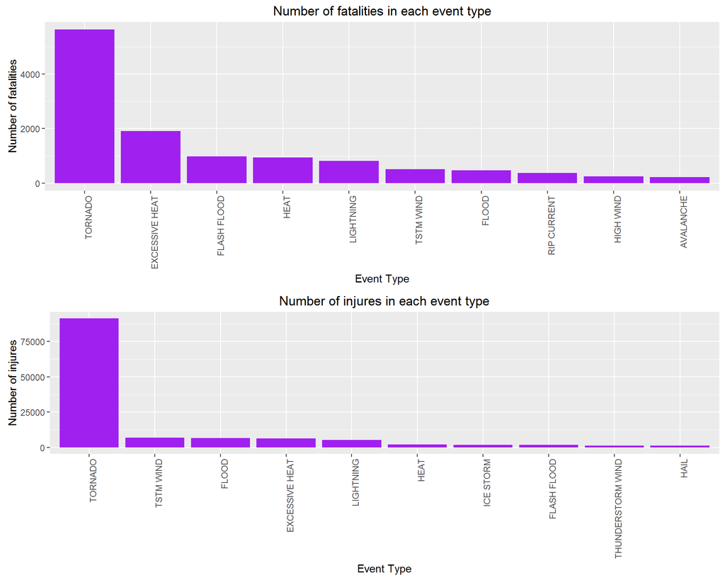

```r
#q 1. here we aggregate data and count injures/fatalities by event type and build figures

# order by number of fatalities and get top 10 of the list
agg_fatalities <- agg_fatalities[order(-agg_fatalities$x),][1:10,]

# order event variables using evtype as factor with levels,
# this operation requiers to plot the graphs with desc order
agg_fatalities$Group.1<- factor(agg_fatalities$Group.1,
                             levels = agg_fatalities$Group.1[-agg_fatalities$x])

# order by number of injures and get top 10 of the list
agg_injures <- agg_injures[order(-agg_injures$x),][1:10,]

# order event variables using evtype as factor with levels,
# this operation requiers to plot the graphs with desc order
agg_injures$Group.1<- factor(agg_injures$Group.1,
                                 levels = agg_injures$Group.1[-agg_injures$x])

ggp1 <- ggplot(agg_fatalities, aes(x=Group.1, y = x)) + geom_bar(stat = "identity", fill = "purple") +
  theme(axis.text.x = element_text(angle = 90, hjust = 1)) + xlab("Event Type") +
  ylab("Number of fatalities") + ggtitle("Number of fatalities in each event type")

ggp2 <- ggplot(agg_injures, aes(x=Group.1, y = x)) + geom_bar(stat = "identity", fill = "purple") +
  theme(axis.text.x = element_text(angle = 90, hjust = 1)) + xlab("Event Type") +
  ylab("Number of injures") + ggtitle("Number of injures in each event type")

grid.arrange(ggp1, ggp2, ncol=1, nrow =2)
```

Getting number of fatalities and injures for top2

```r
agg_injures[1:2,]
```

```
##       Group.1     x
## 834   TORNADO 91346
## 856 TSTM WIND  6957
```

```r
agg_fatalities[1:2,]
```

```
##            Group.1    x
## 834        TORNADO 5633
## 130 EXCESSIVE HEAT 1903
```

As it seems from the graphs:

1. **Tornado** affect most injures and fatalities in the USA, 5633 fatalities and 91346 injures.
2. On the second place by fatalities is **Excessive Heat** (1903 deaths) and by injures is **TSTM Wind** (6957 injures)

## Q2. Across the United States, which types of events have the greatest economic consequences?

Steps to plot the graph:

1. Order by value of property damage
2. Get top 10 of the list
3. Convert evtype to factor.
4. Plot the graps

Similary i do for the crop damage.

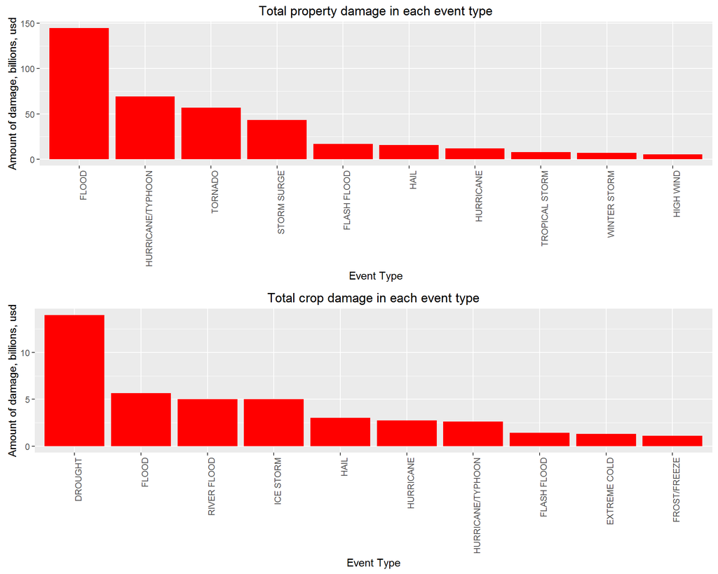

```r
# q 2. here we aggregate data and count total money equivalent of damage done by event type and build figures

# order by damage and get top 10 of the list.
agg_prop_damage <- agg_prop_damage[order(-agg_prop_damage$x),][1:10,]

# order event variables using evtype as factor with levels,
# this operation requiers to plot the graphs with desc order
agg_prop_damage$Group.1<- factor(agg_prop_damage$Group.1,
                                 levels = agg_prop_damage$Group.1[-agg_prop_damage$x])

# order by damage and get top 10 of the list.
agg_crop_damage <- agg_crop_damage[order(-agg_crop_damage$x),][1:10,]

# order event variables using evtype as factor with levels,
# this operation requiers to plot the graphs with desc order
agg_crop_damage$Group.1<- factor(agg_crop_damage$Group.1,
                                 levels = agg_crop_damage$Group.1[-agg_crop_damage$x])

ggp3 <- ggplot(agg_prop_damage, aes(x=Group.1, y = x/10^9)) + geom_bar(stat = "identity", fill = "red") +
  theme(axis.text.x = element_text(angle = 90, hjust = 1))  + xlab("Event Type") +
  ylab("Amount of damage, billions, usd") + ggtitle("Total property damage in each event type")

ggp4 <- ggplot(agg_crop_damage, aes(x=Group.1, y = x/10^9)) + geom_bar(stat = "identity", fill = "red") +
  theme(axis.text.x = element_text(angle = 90, hjust = 1))  + xlab("Event Type") +
  ylab("Amount of damage, billions, usd") + ggtitle("Total crop damage in each event type")

grid.arrange(ggp3, ggp4, ncol=1, nrow =2)
```

Getting value of crop and property damage for top2

```r
agg_crop_damage[1:2,]
```

```
##     Group.1           x
## 95  DROUGHT 13972566000
## 170   FLOOD  5661968450
```

```r
agg_prop_damage[1:2,]
```

```
##               Group.1            x
## 170             FLOOD 144657709800
## 411 HURRICANE/TYPHOON  69305840000
```

As it seems from the graphs:

1. **Flood** affect most property damage in the USA - 144.65 Billions of USD.
2. **Drought** affect most crop damage in the USA - 13.97 Billions of USD.

# Conclusion

Tornado has a most hude affect on peoples lifes, because it causes most number of fatalities and injures. Flood and drought causes most econimic harm. Therefore it is needed to take effort for minimizing harm from these types of weather.